# Lecture 1 Exercises

## Short Questions

1. What is the difference between a list and an array?
2. Consider the list

`list_colors = ["red","yellow","green"]`

What is the output of `list_colors[0]` and  
`list_colors[1]`?

3. How do you concatenate two strings?
4. What does the error "not defined" mean?
5. What does the error "could not be broadcast" mean?
6. How do you compute the median of an array?

```python
# Write your answers here as comments:

import numpy as np
import matplotlib.pyplot as plt
import pandas as pd





#1. The main difference between a list and an array is that a list is a collection of items that can contain elements
# of multiple data types, while an array contains only elements that belong to the same data type.
# Another difference is that arrays can handle arithmetic operations directly while lists cannot,
# but lists can be directly dealed with data cleaning commands.

#2 The output of the first unit of a list in Python has to be obtained from "list[0]"
list_colors = ["red", "yellow", "green"]

print(list_colors[0])
print(list_colors[1])

#3. The easiest way to concatenate two strings is to use "+"


#4. "not defined" error can happen when there is an NameError, meaning that variables are not defined
# or not defined correctly. For example, the error appears if defining nominal variables did not
# include quotation marks.

#5. "could not be broadcast" error happens when mathematical operations
# are conducted on strings that do not have the same size.


#6. use "numPy" library to do mathematical operations and use "median()" command

#for example,

vec_a  = np.array([1,2,3,4,5])
print(np.median(vec_a))
```

```
red
yellow
3.0
```

## Long Questions

(a) Import the pandas and matplotlib packages

```python
# Write your own code

import numpy as np
import matplotlib.pyplot as plt
import pandas as pd
```

(b) Open the dataset "worldbank_wdi_2019.csv"  
in the "data" folder

- Read it as a pandas object called "wdi"
- Note: This is a subset of the World Development Indicators for 2019
- Each observation represents a different country

```python
# Write your own code

wdi = pd.read_csv("data/worldbank_wdi_2019.csv")
```

(c) Browse the dataset and manually create  
a list of variable names

```python
# Write your own code

# Create a list, e.g. "variable_names = [ "name1", "name2", "name3" ]"
# Manually type the names of the variables
# If you're viewing the dataset from the VS-Code "Variables" tool, you'll
# see an extra column "index". Do not include this in your list.

wdi
```

|  | year | country_name | life_expectancy | gdp_per_capita_usd |
| --- | --- | --- | --- | --- |
| 0 | 2019 | Afghanistan | 63.565 | 500.522664 |
| 1 | 2019 | Albania | 79.282 | 5396.215864 |
| 2 | 2019 | Algeria | 76.474 | 4022.150184 |
| 3 | 2019 | American Samoa | NaN | 13672.576660 |
| 4 | 2019 | Andorra | NaN | 41327.502030 |
| ... | ... | ... | ... | ... |
| 266 | NaN | NaN | NaN | NaN |
| 267 | NaN | NaN | NaN | NaN |
| 268 | NaN | NaN | NaN | NaN |
| 269 | Data from database: World Development Indicators | NaN | NaN | NaN |
| 270 | Last Updated: 12/22/2022 | NaN | NaN | NaN |

271 rows × 4 columns

```python
# to create a list that has variable names but can also do summary statistics ,we can do

year = wdi["year"]
country_name = wdi["country_name"]
life_expectancy = wdi["life_expectancy"]
gdp_per_capita = wdi["gdp_per_capita_usd"]


variable_names = [ year, country_name, life_expectancy, gdp_per_capita ]

#or if we only want a list of variable names, we can have

v_names = wdi.columns.tolist()

# which is the same as typing manually
```

(d) Compute descriptive statistics for the fourth  
variable in the dataset

- One way to do this is:

wdi["gdp_per_capita_usd"].describe()

- Do something similar, but with the list you created above.
- Substitute "gdp_per_capita_usd" with a command that

automatically extracts the fourth element in the list

```python
# Write your own code

# Remember that the numbering in Python starts at zero
# For example:
# list_colors = ["red","green","yellow"]
# list_colors[2] will output "yellow"


#try the first approach
wdi["gdp_per_capita_usd"].describe()
```

```
count       255.000000
mean      17230.949757
std       25792.183785
min         216.972968
25%        2186.046581
50%        6837.717826
75%       19809.323135
max      199377.481800
Name: gdp_per_capita_usd, dtype: float64
```

```python
#then we can derive summary statistics from the list

print(variable_names[3].describe())


# or keep the data frame format and only use the list of "variable names"


print(wdi[v_names[3]].describe())
```

```
count       255.000000
mean      17230.949757
std       25792.183785
min         216.972968
25%        2186.046581
50%        6837.717826
75%       19809.323135
max      199377.481800
Name: gdp_per_capita_usd, dtype: float64
count       255.000000
mean      17230.949757
std       25792.183785
min         216.972968
25%        2186.046581
50%        6837.717826
75%       19809.323135
max      199377.481800
Name: gdp_per_capita_usd, dtype: float64
```

(e) Show a scatter plot that shows "gdp_per_capita_usd"  
in the x-axis and "lifexpectancy" in the y-axis. Label the axes.

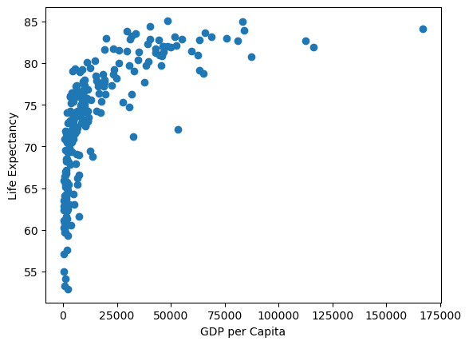

```python
# Write your own code

plt.scatter(x = wdi['gdp_per_capita_usd'], y = wdi['life_expectancy'])
plt.xlabel("GDP per Capita")
plt.ylabel("Life Expectancy")

plt.show()
```

(f) Generate "vec_x" from a chi-square  
distribution with (df = 1, size = 1000)

- Plot a histogram of each variable, with axis labels, and title
- Create a new variable "vec_y" by the formula

$ y = e^x + 2x + 5$

- Plot "vec_x" against "vec_y" and label the axes

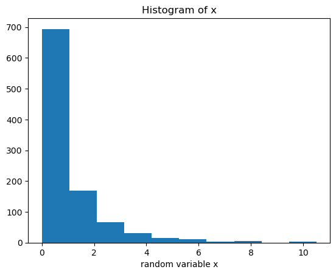

```python
# Write your own code


np.random.seed(800)

vec_x = np.random.chisquare(df=1, size =1000)

plt.hist(x= vec_x, bins = 10)
plt.xlabel("random variable x")
plt.title("Histogram of x")

plt.show()
```

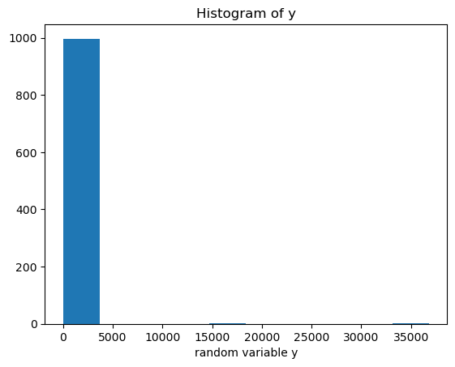

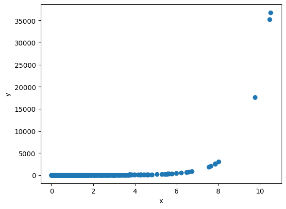

```python
vec_y = np.exp(1)** vec_x + 2*vec_x + 5


plt.hist(x= vec_y, bins = 10)
plt.xlabel("random variable y")
plt.title("Histogram of y")

plt.show()



plt.scatter(x=vec_x, y= vec_y)
plt.xlabel("x")
plt.ylabel("y")
plt.show()
```

(g) Research online how to create an array with  
`size = 1000` entries, with all entries equal to one.

- Create a new matrix, `X_mat` that appends a

vector with only ones and "vec_x" from question (f) to form  
a matrix with two columns and 1000 rows

- Compute $(X_{mat}'X_{mat})^{-1}$

```python
# Write your own code

vec_one = np.ones(1000)

X_mat = np.column_stack([vec_one, vec_x])

X_mat_t = np.matrix.transpose(X_mat)

X_t_X = np.dot(X_mat_t,X_mat)
print(np.linalg.inv(X_t_X))
```

```
[[ 0.00149722 -0.00051129]
 [-0.00051129  0.00052576]]
```